# Untitled

Samikshya

2022-10-09

## Chapter 2 :

Question 2.1

```r
library(resampledata)
```

```r
library(ggplot2)
library(tidyverse)
library(dplyr)
```

```r
x <- c(3,5,8,15,20,21,24)

# Find Mean.
result.mean <- mean(x)
result.median <- median(x)

result.mean
```

```
## [1] 13.71429
```

```r
result.median
```

```
## [1] 15
```

Mean of x = 13.7 Median of x = 15

Now calculating the logarithm of data and calculating their mean and median

```r
log.x = log(x)  #Calculate the log

# Calculating the mean and median of the log vlaue of x

resultmean.log.x <- mean(log.x)
resultmedianloglx <-median(log.x)

resultmean.log.x
```

```
## [1] 2.387693
```

```r
resultmedianloglx
```

```
## [1] 2.70805
```

```r
#log.x
```

mean of the logx is 2.39 median of the logx is 2.71

Now calculating ln x and ln m (Calculating if the log of mean is equal to the mean of logged data x)

```r
ln_mean <- log(result.mean)
ln_median <- log(result.median)

ln_mean
```

```
## [1] 2.618438
```

```r
ln_median
```

```
## [1] 2.70805
```

So, when we compare the log of mean in first case, it is equal of 2.61. The mean of the logarithm of x is approximately 2.39. Therefore, they are not equal.

However, the log of the median of x is 2.70 and the median of the logarithm of the x is 2.70, so they are equal.

## Question 2.3

1. No, the mean of f(x) is not the same as f(x1), f(x2) etc
2. No, the median is not the same.
3. They would be same of the function is linear
4. This would happen if function is increasing, decreasing in this case since x1 < x2 < x3 and if the total number of values in function is odd.

## Question 2.4

Question a.

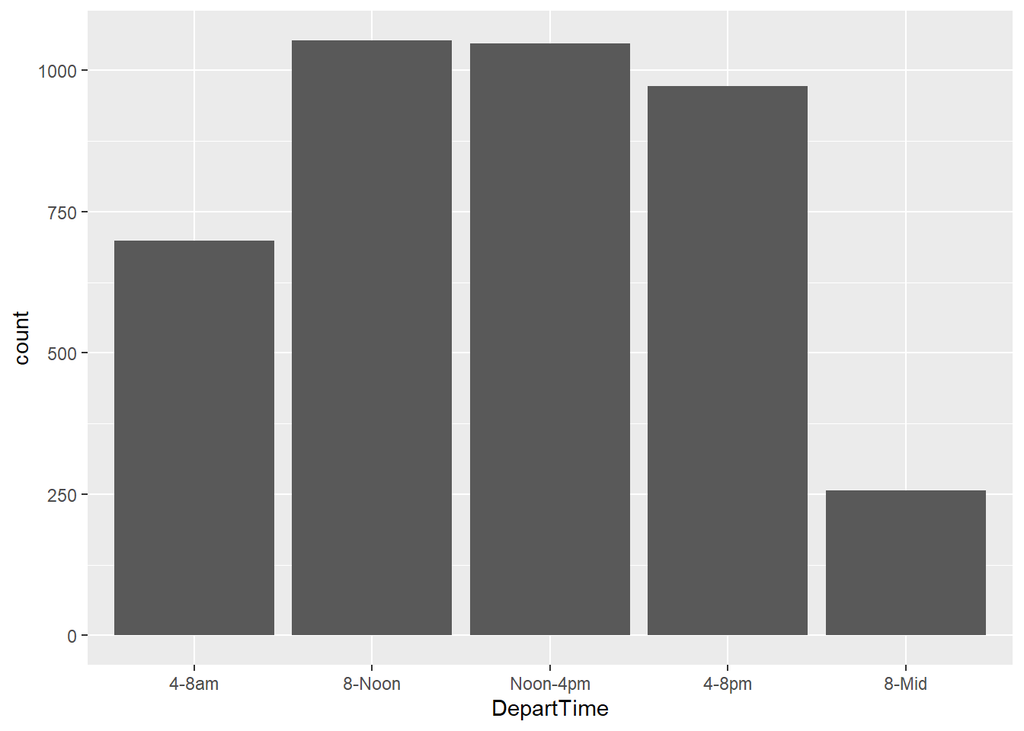

```r
# First importing data:

data(FlightDelays)

#Creating a table for delayed times:


ggplot(data = FlightDelays, mapping = aes( x = DepartTime ))+
  geom_bar()
```

```r
#tab
```

The bargraph above shows the number of flights across different depart time. We see that most of the flights had their departure time between 8am - 8pm.

Question b.

```r
prop.table(table(FlightDelays$Day, FlightDelays$Delayed30), 1 )%>%
  round(3)  #Converting the table into 3 decimal place to make it easier to read.
```

```
##
##          No   Yes
##   Sun 0.920 0.080
##   Mon 0.903 0.097
##   Tue 0.852 0.148
##   Wed 0.865 0.135
##   Thu 0.767 0.233
##   Fri 0.774 0.226
##   Sat 0.896 0.104
```

```r
flight_delays.df <- FlightDelays

names(flight_delays.df)
```

```
##  [1] "ID"           "Carrier"      "FlightNo"     "Destination"  "DepartTime"
##  [6] "Day"          "Month"        "FlightLength" "Delay"        "Delayed30"
```

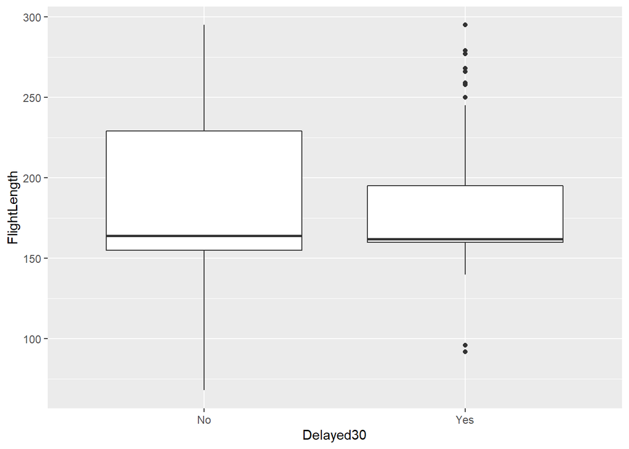

```r
ggplot(data = flight_delays.df, mapping = aes(x = Delayed30,y =  FlightLength)) +
  geom_boxplot()
```

From the boxplot above we can see that there are more variation in flight length of flights that were not delayed by 30 minutes.(The box plots are longer) In plot where the delay was more than 30 minutes, there are outliers with flightlength extending to 300. In the boxplot, the median in closer to 1st quartile. It also indicates that the data is right skewed.

##Question 2.7

```r
library(resampledata)
data(Spruce)

library (dplyr)
```

```r
summary(Spruce$Ht.change)
```

```
##    Min. 1st Qu.  Median    Mean 3rd Qu.    Max.
##    8.30   23.20   30.10   30.93   38.17   51.50
```

```r
#tapply(sporucr$Di,change, spruce$Fertilizer, summary)
#postively related

#color = white

#High kurtosis, normal

#Quantile plot: looks normal. How do understand the normal Q-Q Plot:doesnot follow the q lines. Waves gives us a peak than higher one. Normal  distrubtion with large concentration of boservation in the center.
```

From the summary statistics, the minim of ht.change is 8.30, max is 51.50 and IQR is 14.97

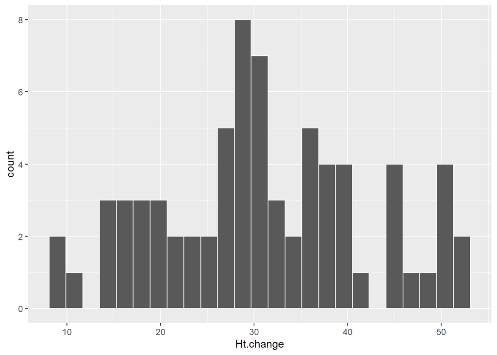

```r
ggplot( data = Spruce, mapping = aes(x = Ht.change))+
  geom_histogram(bins = 25, color = "white")
```

We can see from the histogram figure above that it is a multimodal distribution with few distinct peaks. If we observe the QQ plot below we see that while we see the data tend to follow the straight lines, there are discontinuity in the plot points, mirroring the multiple peaks in the histogram. the tails also seems to be skewed. So I dont think the height change closely follows normal distributions.

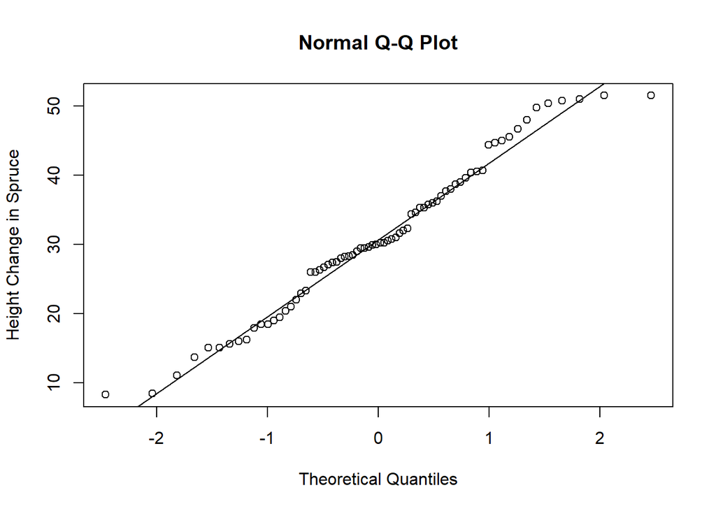

```r
qqnorm(Spruce$Ht.change,
         ylab = "Height Change in Spruce")

qqline(Spruce$Ht.change)
```

c)

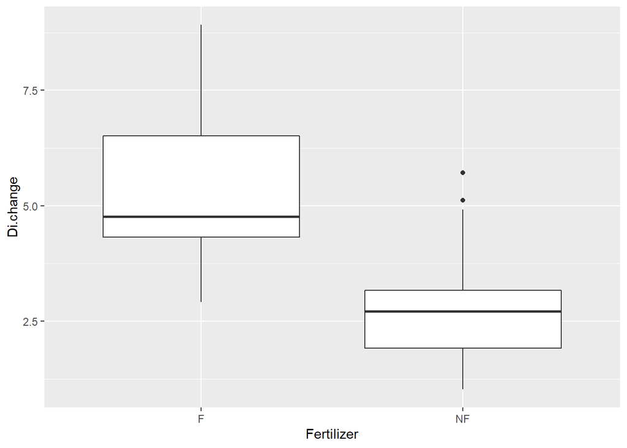

```r
#head(Spruce, 10)
ggplot(data = Spruce, mapping = aes(x = Fertilizer ,y = Di.change))+
  geom_boxplot()
```

From the boxplot above we can see that there is a large change in di.change for those who were in the fertilized plants (Fertilizer F). The diameter change was also right skewed (higher values after median) for fertilized pots. The non-fertilzied pots had smaller diameter change with exception of few outliers.

```r
tapply(Spruce$Di.change, Spruce$Fertilizer, summary)
```

```
## $F
##    Min. 1st Qu.  Median    Mean 3rd Qu.    Max.
##   2.913   4.318   4.763   5.274   6.518   8.919
##
## $NF
##    Min. 1st Qu.  Median    Mean 3rd Qu.    Max.
##   1.019   1.915   2.712   2.718   3.165   5.713
```

With the summary we can see the difference in min and max for the fertilized and non-fertilized pots. The mean is also significantly higher for thefertilzied pot.

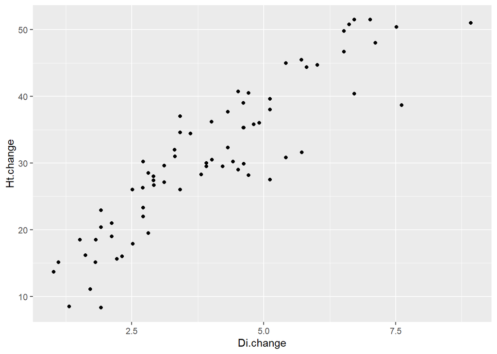

```r
ggplot(data = Spruce, aes(x = Di.change, y = Ht.change ))+
  geom_point()
```

## Question 2.8

```r
data(MobileAds)
```

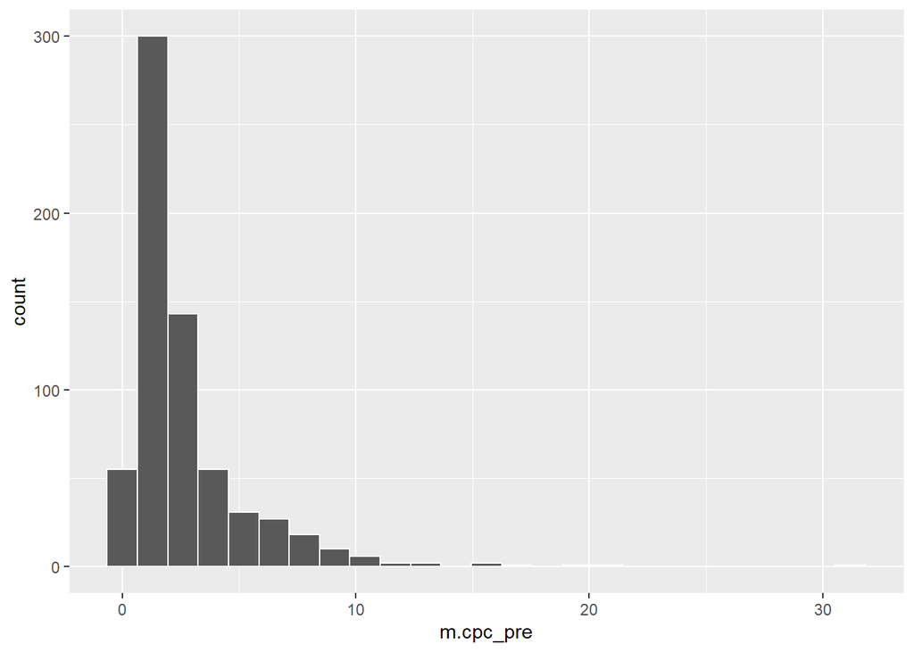

```r
#plotting the cost per click pre
ggplot( data = MobileAds, mapping = aes(x = m.cpc_pre                     ))+
  geom_histogram(bins = 25, color = "white")
```

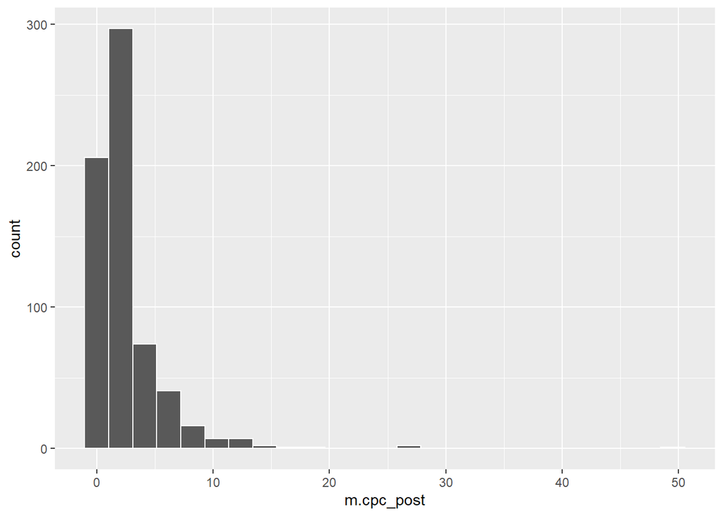

```r
#plotting the cost per click post
ggplot( data = MobileAds, mapping = aes(x = m.cpc_post))+
  geom_histogram(bins = 25, color = "white")
```

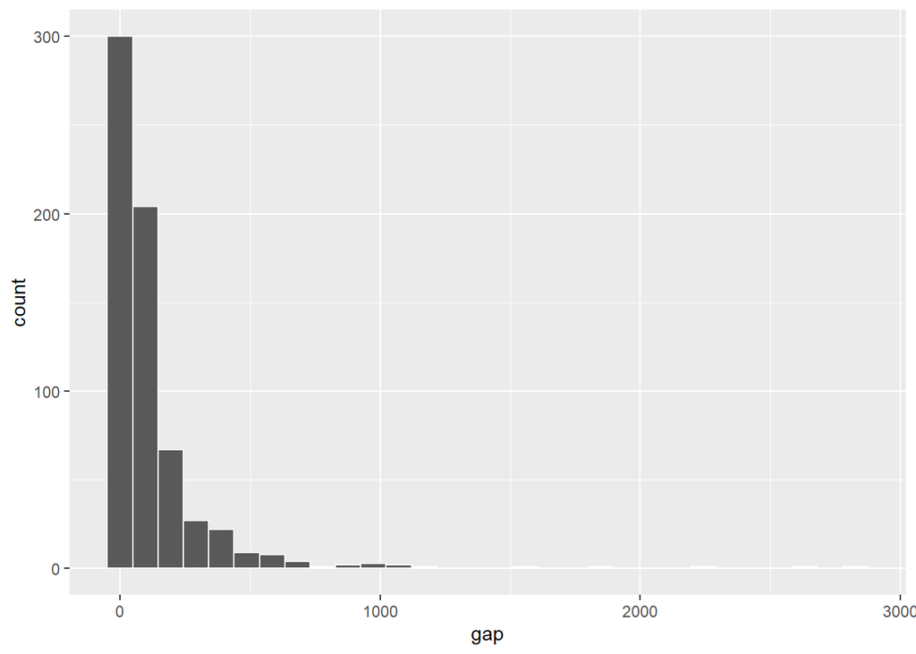

```r
gap <-  abs(MobileAds$m.cost_pre - MobileAds$m.cpc_post)
#absolute value to capture the gap
#Plotting the histogram

ggplot( data = MobileAds, mapping = aes(x = gap))+
  geom_histogram(bins = 30, color = "white")
```

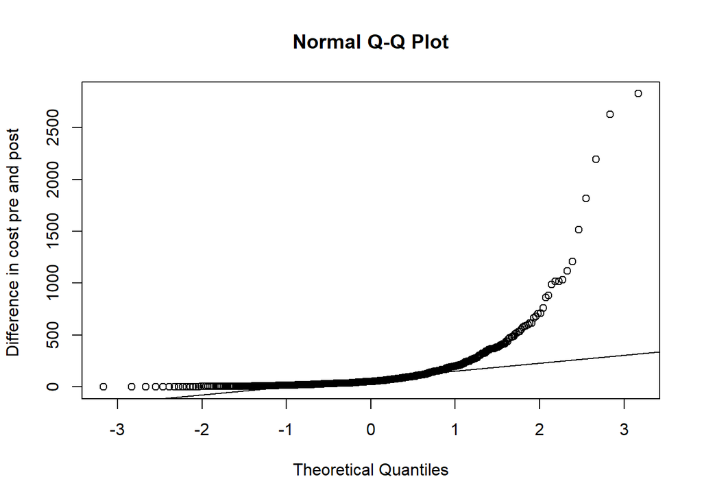

```r
qqnorm(gap,ylab = "Difference in cost pre and post ")

qqline(gap)
```

From the normal plot, we can see the norm closely follows the line till 1 but then it curves towards the end, indicating it has postive kurtosis as well as it is positive skewed.

## CHAPTER 3 HOMEWORK:

## Question 3.3

1. p value of 0.006 provides a stronger evidence for the alternative hypothesis because p value of 0.006 means that , if the null hypothesis were indeed true, there would be 6 in 1000 chance of observing results as extreme as we calculated. Compared to this, p value of 0.03 mean that there would 30 in 1000 chances of observing our data. Therefore, p value of 0.006 is more robust.

In first case, the test is two sided tail test because the null is mean of sample 1 = mean of sample 2. Where as in second scenario Ha it is a one sided tail tests.

2. The p value of 0.095 provided a stronger evidence that chance alone might account for the observed result when compared to 0.04 value.

##Question 3.5

```r
data <- FlightDelays

ls(FlightDelays)
```

```
##  [1] "Carrier"      "Day"          "Delay"        "Delayed30"    "DepartTime"
##  [6] "Destination"  "FlightLength" "FlightNo"     "ID"           "Month"
```

```r
delay.time.AA <- FlightDelays %>%
  filter (Carrier == "AA" )  %>%
  summarize (mean_late.AA = mean(Delay), na.rm = TRUE)  #Calculated the mean of delaye by American Airlines


delay.time.UA <- FlightDelays %>%
  filter (Carrier == "UA" )  %>%
  summarize (mean_late.UA = mean(Delay), na.rm = TRUE)   #Calculate the mean of delay by UA

#Calculate the difference in mean delay times between two carriers.

observed.carrier <- (delay.time.UA$mean_late.UA - delay.time.AA$mean_late.AA)

observed.carrier
```

```
## [1] 5.885696
```

```r
## The observed mean difference in delay time is 5.885696
```

```r
#N = number of simulations we will use
N <- 10^4 -1

sample.size = nrow(FlightDelays)  #sample.size  #The sample size is 4029
#glimpse (FlightDelays)

first_group = nrow(FlightDelays[FlightDelays$Carrier=="UA",])
first_group  #Number of sample in first group is 1123
```

```
## [1] 1123
```

```r
#Creating a blank vector to store the simulation results

result.mean.simulation <- numeric(N)

#use loop to to run this

for (i in 1:N) {
  index = sample(sample.size, size = first_group, replace = FALSE)

#calculate the difference between two simulated groups

  result.mean.simulation[i] <- mean(FlightDelays$Delay[index]) - mean(FlightDelays$Delay[- index], )
}
```

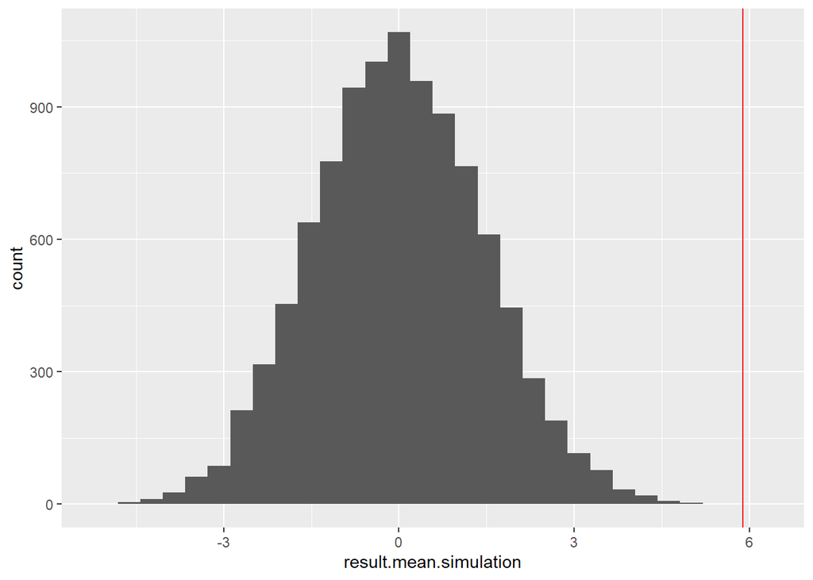

```r
ggplot(data = tibble(result.mean.simulation), mapping = aes(x=result.mean.simulation)) +
  geom_histogram() +
  geom_vline(xintercept = observed.carrier, color = "red")
```

```r
#Calculate the p-value
# We use greater than because of the position of the red line i.e observed mean
pvalue.carrier <- ((min(sum(result.mean.simulation >=  observed.carrier), sum(result.mean.simulation <= observed.carrier))+ 1) / (N + 1))  * 2

pvalue.carrier
```

```
## [1] 4e-04
```

Question 3.5 B)

```r
data <- FlightDelays

ls(data)
```

```
##  [1] "Carrier"      "Day"          "Delay"        "Delayed30"    "DepartTime"
##  [6] "Destination"  "FlightLength" "FlightNo"     "ID"           "Month"
```

```r
delay.time.May <- data %>%
  filter (Month == "May")%>%
  summarize (mean_late.May = mean(Delay), na.rm = TRUE)  #Calculated the mean of delayed by May
  delay.time.May
```

```
##   mean_late.May na.rm
## 1      8.884442  TRUE
```

```r
delay.time.June <- data%>%
  filter (Month == "June")  %>%
  summarize (mean_late.June = mean(Delay), na.rm = TRUE)   #Calculate the mean of delay on month of June
  delay.time.June
```

```
##   mean_late.June na.rm
## 1       14.54778  TRUE
```

```r
# Calculating the difference between these two month

obs.meandiff.month <- abs(delay.time.May  - delay.time.June)

obs.meandiff.month  #The observed mean difference of month is 5.66
```

```
##   mean_late.May na.rm
## 1      5.663341     0
```

```r
N <- 10^4 -1

#sample.size = the number of observations in our sample
sample.size = nrow(data)
#sample.size

group.1.May = nrow(FlightDelays[FlightDelays$Month =="May",])
group.1.May
```

```
## [1] 1999
```

```r
result.month <- numeric(N)


for(i in 1:N)
{index = sample(sample.size, size=group.1.May, replace = FALSE)


  result.month[i] = mean(FlightDelays$Delay[index]) - mean(FlightDelays$Delay[-index],)
}
```

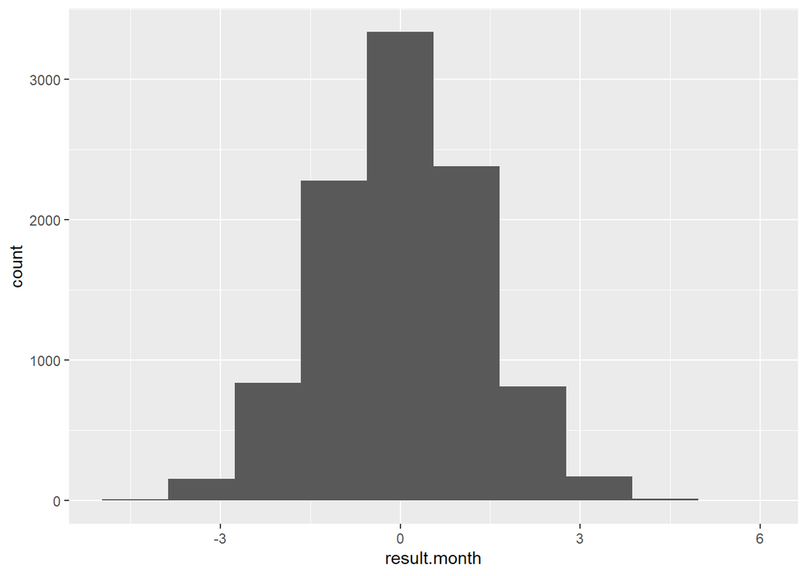

```r
#plot a histogram of the simulated differences
#add a vertical line at the observed difference

ggplot(data = tibble(result.month), mapping = aes(x= result.month))+
  geom_histogram(bins = 10)
```

```r
  xlim(-25,50000)
```

```
## <ScaleContinuousPosition>
##  Range:
##  Limits:  -25 -- 5e+04
```

```r
  geom_vline(xintercept= obs.meandiff.month, color = "red")
```

```
## mapping: xintercept = ~xintercept
## geom_vline: na.rm = FALSE
## stat_identity: na.rm = FALSE
## position_identity
```

```r
#Calculate the p-value

  head(result.month, 15)
```

```
##  [1]  0.29779619  2.06409584 -4.33985737  2.32223969  0.41495378 -0.36543493
##  [7]  1.32937873 -0.25919881  0.42885384  0.05553811  1.21122827  0.93819151
## [13]  0.23226737 -0.41607084  3.09567838
```

```r
pvalue.month <- ((sum(result.month >= obs.meandiff.month) + 1) / (N + 1)) * 2

#Because the observed difference is 5. the right side of the graph we use the ">"  greater than test to calculate p value

pvalue.month
```

```
## [1] 4e-04
```

The p value is really really small so we can reject the null in the favor of alternative. Therefore. we can say that there is enough evidence to indicate that the mean delay times between two months is statistically significant and are not equal.